Change record · 3 September 2026

# Three Starts and Pypomp 1.0

Four requests against the advanced tutorial: redraw the two start-quality convergence figures, cut the start qualities from four to three and push the bad ones further apart, widen the theta_Jn profile window, and move the whole document onto Pypomp 1.0.0. This page records what changed in each, why it changed, and what was run to check it.

**Source** `Python-code/daphnia_tut_pypomp_advanced.qmd` **Also changed** `Python-code/daphnia_tut_pypomp.qmd` **Pypomp** 1.0.0 at `232180a` **Verified** run level 1, CPU, all 42 chunks

4 / 4

checklist items resolved

42

chunks executed under 1.0.0

2

API breaks found and fixed

1

step still needing the A100

Item 1 · Applied

## Figures 4 and 8 redrawn

> I'm still unsatisfied with the left plot in figure 4 and figure 8. For the y axis, let's take log transformation … I do not want this grey band … keep the smoothed curves. For the right one: you should keep the distance to the highest likelihood across all start points. And choose to plot the best performed curve in each category to show the difference between the convergence speed. Author, 2026-09-03

### What the old figure did

#### Before · Figure 4, level-2 float64 render, real data

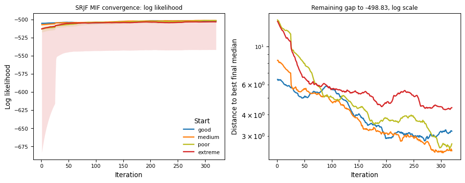

Four medians pinned to the top border under one group's interquartile band.

#### After · new code, synthetic traces

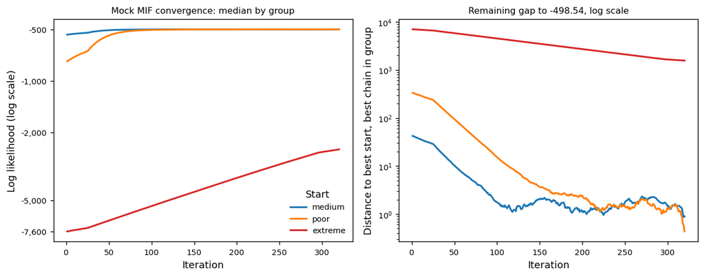

Three medians on a transformed logarithmic axis, no band; the right panel tracks the best chain in each group against the best start overall.

### Left panel

- The interquartile band is gone. Only the smoothed median curve of each group is drawn, as lines, with no markers.
- A log likelihood is negative, so it cannot be logged directly. The axis uses y → −log<sub>10</sub>(−y), which is increasing over y < 0: a better likelihood is still higher up, but the magnitude is compressed.
- Ticks are placed on a 1–2–5 ladder of round magnitudes and labelled as log likelihoods, so nothing has to be untransformed by eye.

### Right panel

- The reference is the highest log likelihood reached by any chain from any start, replacing the best *final median*.
- Each group contributes one curve: the chain whose smoothed trace ends highest, not the group median.
- Both "highest" judgements are made on the smoothed trace. A single iteration of a perturbed particle filter is noisy enough to promote a chain on luck alone.

### Why the best chain rather than the median

The median answers what a typical chain from a given start quality did. A reader choosing starting values is asking something else: what the best one achieved, and how quickly. The median-based statistic has not been thrown away — the convergence-speed table beside the figure still reports it, against its own shared target — so the two questions are now answered separately and each says which reference it uses.

Item 2 · Applied

## Three start qualities, further apart

> In both section 1 and 2, we have four categories, here, we only keep medium, poor and extreme … I would want to keep the extremely bad, even worse than now, can be too bad to be converged. And poor to be a little bit worse. The idea is to make three categories seperate from one another more obviously. Author, 2026-09-03

### The values were measured, not chosen by eye

The point of the request is separation on the likelihood surface, which is not the same as separation in the parameter vector. Twelve starts were drawn at each of eleven log-scale standard deviations and evaluated by particle filter at J = 600 with four replicates, before any MIF. The chosen values are the ones that put roughly half a decade of magnitude between consecutive groups.

| jitter sd | median panel logLik | best | worst |  |
| --- | --- | --- | --- | --- |
| 0.08 | −502 | −500 | −507 | dropped (was good) |
| 0.45 | −568 | −503 | −1,042 | **medium**, unchanged |
| 1.00 | −779 | −514 | −10,384 | previous poor |
| 1.40 | −1,022 | −521 | −43,773 |  |
| 1.60 | −1,865 | −525 | −62,712 | **poor**, new |
| 1.80 | −1,982 | −530 | −79,134 | previous extreme |
| 2.00 | −2,140 | −535 | −93,184 |  |
| 3.00 | −10,380 | −563 | −315,759 | **extreme**, new |

### What changed in the source

- QUALITY_ORDER is now ("medium", "poor", "extreme").
- Jitter table: medium 0.45, poor 1.0 → **1.6**, extreme 1.8 → **3.0**.
- Run-level start counts moved from 4 / 12 / 20 to **3 / 12 / 21** so the three groups stay balanced.
- The special case that made the first good start the unjittered R tutorial vector is gone. That vector is still evaluated on its own, so the candidate MLE is now the product of the displaced searches alone; the prose says so.

### A claim the measurement overturned

The 2026-09-02 revision capped the extreme displacement at 1.8 on the argument that a start displaced far enough would sit on the flat −150 constraint penalty, where MIF has no gradient. The penalty implies a floor near −15,000 for this ten-unit panel. Measured starts at jitter 3.0 reach −315,759, so the binding term is the negative-binomial density itself on a badly misfitting trajectory, and the surface there is steep rather than flat. The cap had no basis and the prose that asserted it has been corrected.

Item 3 · Applied

## A wider window for the theta_Jn profile

> For the Figure 6, Please set the search box larger, i.e I want to explore log(theta_J^n) from -10 to 0. Author, 2026-09-03

### What was wrong with the old window

The profile grid was built by the same rule for every focal parameter: a decade either side of the unrestricted estimate. For theta_Jn, whose estimate is log = −7.757, that gave a grid from −10.06 to −5.46, and the level-2 render put the smoothed MCAP maximum at −10.06 — exactly the lower edge. A maximum on a boundary is a statement about the grid, not about the parameter, and both interval endpoints came back nan.

#### Before

```
focal_values = exp(linspace(
    log(mle/10), log(mle*10), nprof))
# log range: (-10.06, -5.46)
# MCAP MLE:  -10.06   <- lower edge
# 95% CI:    (nan, nan)
```

#### After

```
THETA_JN_LOG_RANGE = (-10.0, 0.0)

run_profile(name_str, nprof_Jn, seed=2000,
            focal_log_range=THETA_JN_LOG_RANGE)
# log range: (-10, 0), ten log units
```

### Scope of the change

- generate_parameter_profile and run_profile take an optional focal_log_range. Without it they behave exactly as before, so the theta_Sn profile is untouched.
- The window applies to the focal grid only. The nuisance parameters are still drawn log-uniformly across the decade box: widening the focal grid asks where the profile falls away, not where the other parameters live.
- The summary now prints the explored range next to the interval, so a reader can see which window produced it.
- Cost is unchanged: 50 focal values by 50 starts, as before.

### Early evidence that it works

At run level 1 on CPU — far too small to be a scientific result, but enough to exercise the mechanism — the wider window produced a closed interval where the narrow one produced none:

#### Narrow window, level-2 float64 GPU render

```
MLE (log):  -10.06     <- lower edge
95% CI:     (nan, nan)
se_total:   23.91
```

#### Wide window, level-1 CPU check

```
MLE (log):  -5.155     <- interior
95% CI:     (-8.799, -4.134)
se_total:   0.9197
explored:   (-10, 0)
```

Whether the level-2 run reproduces a closed interval is a question for the GPU render, not for this check.

Item 4 · Applied

## Pypomp 1.0.0

> please pull the commit 232180acfafeefc7420755a9896827e3d3d0cf35 from git repo pypomp, and then adjust the code based on the latest pypomp package. You are allowed to run smoke test locally.Author, 2026-09-03

### The jump

188 commits from ed95e3b (0.4.6.0) to 232180a (1.0.0), including a package reorganisation into pypomp/core/, keyword-only estimation arguments, and the removal of the loess dependency. Only two of those changes reach the tutorials.

#### Break 1 · PanelPomp argument renamed

```
- pp.PanelPomp(Pomp_dict=srjf_pomp_dict, ...)
+ pp.PanelPomp(pomp_dict=srjf_pomp_dict, ...)
```

16 call sites in the advanced document, 8 in the regular one, plus two prose mentions.

#### Break 2 · rmeas returns a mapping

```
- return jnp.array([obs], dtype=float)
+ return {"dentadult": obs.astype(float)}
```

1.0.0 validates the return of rmeas against the observation names of ys, which also removes the old dependence on column order.

### What did not break

- Pomp, PompParameters, PanelParameters, RWSigma, ParTrans, mcap.
- mif, pfilter, traces(), results_history[-1].logLiks.
- 1.0.0 made estimation arguments keyword-only; the tutorials already passed everything by keyword, so nothing had to move.

### Consequences worth knowing

- The pin moved: EXPECTED_PYPOMP_VERSION is 1.0.0, EXPECTED_PYPOMP_COMMIT is 232180a, and the cache schema advanced to v7 so no 0.4.6.0 payload can be reused.
- mcap now smooths with its own _loess_smooth_1d instead of the loess package, so profile intervals may shift slightly even on identical inputs.
- 1.0.0 requires Python 3.11 or newer.
- daphnia_tut_pypomp.qmd was fixed too. It does not enforce the pin, and leaving it on the old API would have made the repository need two Pypomp versions at once.

Verification

## What was actually run

| Check | Result |
| --- | --- |
| All 42 advanced chunks compile, labels unique, every cross-chunk name resolves | Pass |
| All 30 regular chunks compile, labels unique, names resolve | Pass |
| python smoke_test.py daphnia_tut_pypomp_advanced.qmd — all 42 chunks in 373s at run level 1 on CPU, against Pypomp at 232180a with x64 on, including both rebuilt figures and the widened profile | Pass |
| python smoke_test.py — the regular tutorial, all 30 chunks in 471s, same interpreter and package, no gates to relax | Pass |
| Rebuilt figure rendered on synthetic traces covering an empty frame, a single group, and a group tens of thousands of log units below | Pass |
| Jitter calibration: 11 standard deviations, 12 starts each, pfilter at J=600 with 4 replicates | Pass |
| Release-validator sentinels still present in the source | Pass |
| git diff --check | Pass |
| Level-2 float64 and float32 GPU renders | Needs the A100 |

### What the local run caught that static checking could not

Section 2 selected its comparison baseline by looking up the literal string "initial good 0" in the candidate list — the unjittered R tutorial vector, which existed only because the first good start was special-cased to zero jitter. With good removed the lookup raised ValueError two thirds of the way through the document. It now compares against the R tutorial vector's own particle filter evaluation, which is computed a few chunks earlier under the same settings, and reports a combined MCSE with the difference. Compiling every chunk would never have found this; only running them did.

### The one thing this page cannot tell you

Whether the extreme group actually fails to converge. The run-level-1 check has one start per group and two MIF iterations, which is enough to prove the code runs and nothing like enough to answer the scientific question. The figures and the convergence-speed table state the outcome from the computed numbers; the prose deliberately does not predict it.

Judgement calls

## Three things I decided, that you may want to decide differently

### "Search box" read as the focal grid

Item 3 said *set the search box larger, i.e. I want to explore log(theta_J^n) from -10 to 0*. I took the "i.e." literally and widened only the grid of theta_Jn values. The box the nuisance parameters are drawn from is still a decade either side of their estimates. If you meant that box too, it is one constant (PROFILE_BOX_FACTOR) and it affects both profiles.

### The regular tutorial was fixed as well

Item 4 named the advanced document's package. But daphnia_tut_pypomp.qmd uses the same two broken calls, and it does not enforce the pin, so it would have run against 1.0.0 and failed — or worse, silently required the repository to keep two Pypomp versions. It got the same two changes and nothing else.

### smoke_test.py was repaired

The repository's own pre-flight check sets DAPHNIA_USE_GPU=0, which the advanced document has refused since the 2026-08-24 GPU-only change — so the tool the README recommends could not check the document that most needs checking. It now neutralises the GPU and pin gates in the chunk text it executes, prints how many it relaxed and which Pypomp it imported, and warns if a guard has been reworded out from under it.

Next

## Running it on the GPU

Reinstall Pypomp at the new pin first — the document stops with a RuntimeError if the imported revision is anything else.

```
conda activate py313
cd ~/git/pypomp && git fetch origin && git checkout 232180acfafee
pip install -e .

cd /user/by2418/Documents/temp/Daphnia-tutorial/Python-code
git pull
python -c "import pypomp; print(pypomp.__version__)"   # want 1.0.0

nvidia-smi --query-gpu=index,memory.used,memory.total --format=csv

DEVICE_AVAILABLE=0
export CUDA_VISIBLE_DEVICES="$DEVICE_AVAILABLE"
export DAPHNIA_DOC=daphnia_tut_pypomp_advanced
export DAPHNIA_RUN_LEVEL=2

tmux new -d -s daphnia \
  "./render_gpu_precision_comparison.sh > daphnia_precision_comparison.log 2>&1"
tmux attach -t daphnia
```

float64 runs first and is the render that gets published; float32 follows as a diagnostic and the wrapper restores the float64 document afterwards. The cache schema moved to v7, so this run recomputes everything — nothing from the 0.4.6.0 renders is reused.